# YouTube_Project

#### Graphical Analysis

Now that the data is all cleaned up, we can answer our research questions

[figure not shown]

[figure not shown]

[figure not shown]

RESEARCH QUESTION 1. : Which categor(ies) of videos are viewed the most on YouTube in the selected countries?

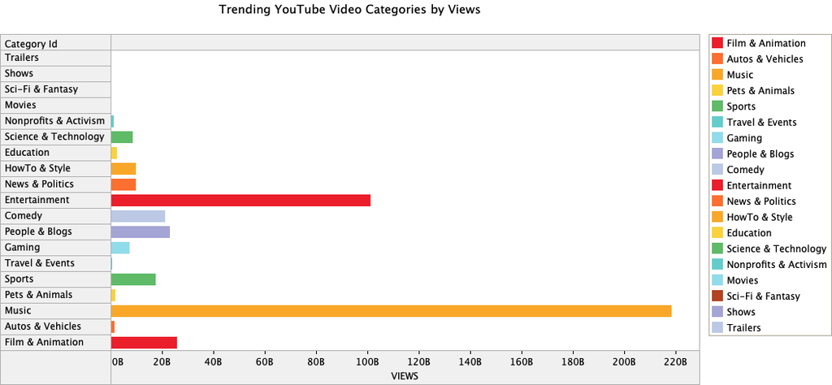

RESEARCH QUESTION 2. Which months have the highest trends in the selected countries?

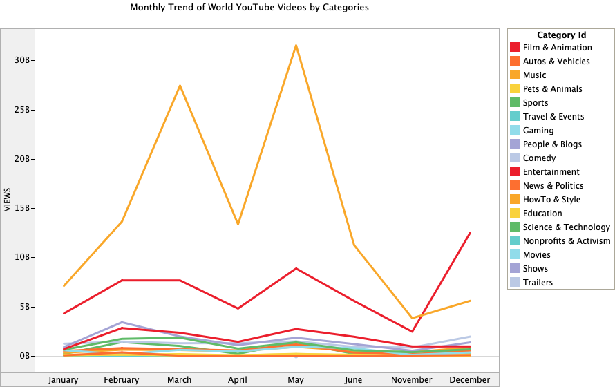

RESEARCH QUESTION 4. Which category has the highest number of user engagement on YouTube (likes)?

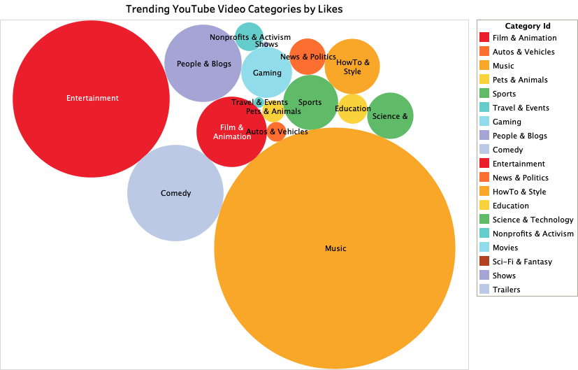